# Redes neuronales con R

## Optimización de hiperparámetros

En este apartado, se muestra cómo afectan al aprendizaje algunos de los hiperparámetros más influyentes. Para ello, se combinan los métodos de *grid search*, *random search* y *early stopping*.

### Grid Search

Búsqueda cartesiana probando todos los valores definidos por el usuario.

```r
# Número de neuronas
# ==============================================================================
hiperparametros <- list(hidden = c(1, 5, 10, 15, 25, 50, 100, 300, 500))

grid_dl <- h2o.grid(
              algorithm      = "deeplearning",
              activation     = "Rectifier",
              adaptive_rate  = FALSE,
              epochs         = 100,
              # Variable respuesta y predictores
              x              = c("x_1", "x_2"),
              y              = "y",
              training_frame = datos_train,
              # validation_frame = datos_validation, # Para validación simple
              nfolds        = 3, # validación cruzada
              standardize   = TRUE,
              hyper_params  = hiperparametros,
              search_criteria = list(strategy = "Cartesian"),
              seed          = 123,
              grid_id       = "grid_dl"
          )
```

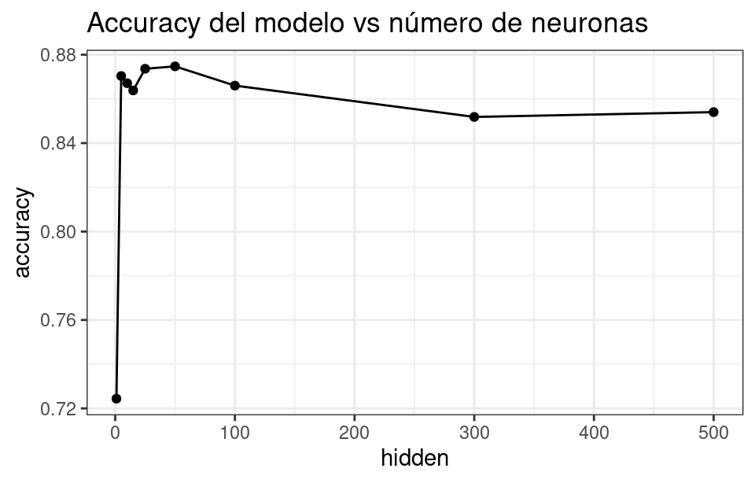

```r
# Se muestran los modelos ordenados de mayor a menor accuracy
resultados_grid <- h2o.getGrid(
                     sort_by = 'accuracy',
                     grid_id = "grid_dl",
                     decreasing = TRUE
                   )

data.frame(resultados_grid@summary_table) %>%
  mutate(
    accuracy = as.numeric(accuracy),
    hidden  = str_remove_all(hidden, pattern = "\\[|\\]"),
    hidden  = as.numeric(hidden),
 ) %>%
  ggplot(aes(x=hidden, y=accuracy, group=1)) +
  geom_line() +
  geom_point() +
  labs(title="Accuracy del modelo vs número de neuronas") +
  theme_bw()
```

```r
# Learning rate
# ==============================================================================
hiperparametros <- list(rate = c(0.00001, 0.0001, 0.0001, 0.001, 0.01, 0.1, 1, 10))

grid_dl_2 <- h2o.grid(
              algorithm      = "deeplearning",
              activation     = "Rectifier",
              adaptive_rate  = FALSE,
              rate_annealing = 0,
              rate_decay     = 0,
              nesterov_accelerated_gradient = FALSE,
              hidden         = 10,
              epochs         = 50,
              x              = c("x_1", "x_2"),
              y              = "y",
              training_frame = datos_train,
              # validation_frame = datos_validation, # Para validación simple
              nfolds         = 3, # validación cruzada
              standardize    = TRUE,
              hyper_params   = hiperparametros,
              search_criteria = list(strategy = "Cartesian"),
              seed           = 123,
              grid_id        = "grid_dl_2"
          )
```

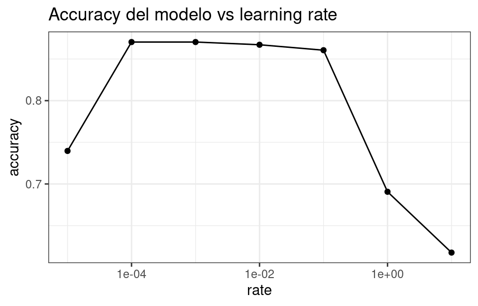

```r
# Se muestran los modelos ordenados de mayor a menor accuracy
resultados_grid <- h2o.getGrid(
                     sort_by = 'accuracy',
                     grid_id = "grid_dl_2",
                     decreasing = TRUE
                   )

data.frame(resultados_grid@summary_table) %>% select(-model_ids) %>%
  mutate(accuracy = as.numeric(accuracy),
         rate    = as.numeric(rate)) %>%
  ggplot(aes(x=rate, y=accuracy, group=1)) +
  scale_x_continuous(trans='log10') +
  geom_line() +
  geom_point() +
  labs(title="Accuracy del modelo vs learning rate") +
  theme_bw()
```

Si bien los dos ejemplos anteriores sirven para tener una idea intuitiva de cómo afecta cada hiperparámetro, no es posible optimizarlos de forma individual, ya que el impacto final que tiene cada uno depende de qué valor tomen los demás. La búsqueda de hiperparámetros debe hacerse en conjunto.

```r
# Learning rate + número de neuronas
# ==============================================================================
hiperparametros <- list(
                      rate = c(0.00001, 0.0001, 0.0001, 0.001, 0.01, 0.1, 1),
                      hidden = c(1, 5, 10, 15, 25, 50, 100, 300, 500)
                    )

grid_dl_3 <- h2o.grid(
              algorithm      = "deeplearning",
              activation     = "Rectifier",
              adaptive_rate  = FALSE,
              rate_annealing = 0,
              rate_decay     = 0,
              nesterov_accelerated_gradient = FALSE,
              epochs         = 50,
              x              = c("x_1", "x_2"),
              y              = "y",
              training_frame = datos_train,
              # validation_frame = datos_validation, # Para validación simple
              nfolds         = 3, # validación cruzada
              standardize    = TRUE,
              hyper_params   = hiperparametros,
              search_criteria = list(strategy = "Cartesian"),
              seed           = 123,
              grid_id        = "grid_dl_3"
          )

resultados_grid <- h2o.getGrid(
                     sort_by = 'accuracy',
                     grid_id = "grid_dl_3",
                     decreasing = TRUE
                   )

data.frame(resultados_grid@summary_table)
```

| hidden | rate | model_ids | accuracy |
| --- | --- | --- | --- |
| [15] | 0.1 | grid_dl_3_model_49 | 0.8758169934640523 |
| [10] | 1.0E-4 | grid_dl_3_model_12 | 0.8736383442265795 |
| [10] | 0.001 | grid_dl_3_model_30 | 0.8736383442265795 |
| [500] | 1.0E-5 | grid_dl_3_model_9 | 0.8736383442265795 |
| [300] | 1.0E-4 | grid_dl_3_model_17 | 0.8725490196078431 |
| [500] | 1.0 | grid_dl_3_model_63 | 0.8725490196078431 |
| [300] | 1.0E-5 | grid_dl_3_model_8 | 0.8725490196078431 |
| [25] | 1.0E-4 | grid_dl_3_model_14 | 0.8714596949891067 |
| [500] | 1.0E-4 | grid_dl_3_model_18 | 0.8714596949891067 |
| [10] | 0.01 | grid_dl_3_model_39 | 0.8714596949891067 |

[output cut: 44 more lines]

### Detención temprana del entrenamiento (*Early Stopping*)

Una de las características de los modelos de deep learning es que, con el número suficiente de épocas, el modelo final tiende a ajustarse perfectamente a los datos de entrenamiento causando *overfitting*. Este comportamiento implica que el analista tiene que encontrar el número adecuado de épocas y, para ello, suele tener que entrenar el modelo con cientos o miles de épocas hasta identificar el momento en el que empieza el *overfitting*. Esto suele ser poco eficiente en términos de tiempo, ya que, posiblemente, se estén realizando iteraciones innecesarias.

De nuevo, la experiencia de los creadores de **H2O** queda reflejada en su herramienta, esta vez incluyendo toda una serie de estrategias para detener el proceso de ajuste de un modelo *Deeplearning* a partir del momento en el que este deja de mejorar. Por defecto, la métrica empleada se calcula con los datos de validación. Tres argumentos controlan la estrategia de parada:

- `stopping_metric`: métrica empleada para cuantificar cuánto mejora el modelo.
- `stopping_tolerance`: porcentaje mínimo de mejora entre dos mediciones consecutivas por debajo del cual se considera que el modelo no ha mejorado.
- `stopping_rounds`: número de mediciones consecutivas en las que no se debe superar el `stopping_tolerance` para que el algoritmo se detenga.

Algunos ejemplos de criterios de parada son:

- Detener el entrenamiento de un modelo cuando el error de clasificación no se reduce más de un 1% durante dos mediciones consecutivas: `stopping_rounds=2`, `stopping_tolerance=0.01` y `stopping_metric="misclassification"`.
- Detener el entrenamiento de un modelo cuando el *logloss* no se reduce nada durante 3 mediciones consecutivas: `stopping_rounds=3`, `stopping_tolerance=0` y `stopping_metric="logloss"`.
- Detener el entrenamiento de un modelo cuando la media de *AUC* no aumenta más de un 0.1% durante cinco mediciones consecutivas: `stopping_rounds=5`, `stopping_tolerance=0.001` y `stopping_metric="AUC"`.

También es posible detener el entrenamiento del modelo cuando se supera un tiempo máximo especificado con el argumento `max_runtimesecs > 0`.

```r
modelo <- h2o.deeplearning(
                      x = c("x_1", "x_2"),
                      y = "y",
                      distribution    = "multinomial",
                      training_frame  = datos_train,
                      validation_frame = datos_validation,
                      standardize     = TRUE,
                      activation      = "Rectifier",
                      adaptive_rate   = FALSE,
                      rate            = 0.1,
                      hidden          = 10,
                      stopping_rounds = 5,
                      stopping_metric = "misclassification",
                      stopping_tolerance = 0.001,
                      score_validation_samples = 1000,
                      epochs          = 100000000, # Múchas epocas
                      seed            = 123
          )
```

```r
modelo@model$scoring_history
```

| timestamp | duration | training_speed | epochs | iterations | samples | training_rmse | training_logloss | training_r2 | training_classification_error | training_auc | training_pr_auc | validation_rmse | validation_logloss | validation_r2 | validation_classification_error | validation_auc | validation_pr_auc |
| --- | --- | --- | --- | --- | --- | --- | --- | --- | --- | --- | --- | --- | --- | --- | --- | --- | --- |
| 2021-07-11 17:56:32 | 0.000 sec | NA | 0 | 0 | 0 | NaN | NaN | NaN | NaN | NaN | NaN | NaN | NaN | NaN | NaN | NaN | NaN |
| 2021-07-11 17:56:32 | 0.010 sec | 1311428 obs/sec | 10 | 1 | 9180 | 0.3274581 | 0.3644779 | 0.8364554 | 0.1383442 | NaN | NaN | 0.3435766 | 0.3681430 | 0.8222076 | 0.1565836 | NaN | NaN |
| 2021-07-11 17:56:37 | 5.015 sec | 1520534 obs/sec | 8300 | 830 | 7619400 | 0.3120635 | 0.3082823 | 0.8514712 | 0.1198257 | NaN | NaN | 0.3417770 | 0.3716734 | 0.8240653 | 0.1530249 | NaN | NaN |
| 2021-07-11 17:56:42 | 10.018 sec | 1536723 obs/sec | 16760 | 1676 | 15385680 | 0.3189680 | 0.3138540 | 0.8448260 | 0.1241830 | NaN | NaN | 0.3249403 | 0.3264790 | 0.8409722 | 0.1387900 | NaN | NaN |
| 2021-07-11 17:56:47 | 15.021 sec | 1529796 obs/sec | 25020 | 2502 | 22968360 | 0.3156584 | 0.3101483 | 0.8480294 | 0.1274510 | NaN | NaN | 0.3197381 | 0.3111963 | 0.8460234 | 0.1281139 | NaN | NaN |
| 2021-07-11 17:56:52 | 20.025 sec | 1510661 obs/sec | 32940 | 3294 | 30238920 | 0.3207649 | 0.3178751 | 0.8430727 | 0.1339869 | NaN | NaN | 0.3291053 | 0.3232207 | 0.8368693 | 0.1423488 | NaN | NaN |
| 2021-07-11 17:56:57 | 25.031 sec | 1479307 obs/sec | 40320 | 4032 | 37013760 | 0.3104608 | 0.3038888 | 0.8529929 | 0.1241830 | NaN | NaN | 0.3166679 | 0.3149125 | 0.8489662 | 0.1281139 | NaN | NaN |
| 2021-07-11 17:57:02 | 30.036 sec | 1409226 obs/sec | 46090 | 4609 | 42310620 | 0.3069477 | 0.2986878 | 0.8563011 | 0.1241830 | NaN | NaN | 0.3294374 | 0.3380871 | 0.8365399 | 0.1494662 | NaN | NaN |
| 2021-07-11 17:57:07 | 35.040 sec | 1395372 obs/sec | 53240 | 5324 | 48874320 | 0.3086797 | 0.3030367 | 0.8546748 | 0.1220044 | NaN | NaN | 0.3227381 | 0.3268536 | 0.8431204 | 0.1316726 | NaN | NaN |
| 2021-07-11 17:57:12 | 40.046 sec | 1403028 obs/sec | 61180 | 6118 | 56163240 | 0.3080161 | 0.2998465 | 0.8552990 | 0.1220044 | NaN | NaN | 0.3294879 | 0.3377822 | 0.8364898 | 0.1565836 | NaN | NaN |

[output cut: 11 more lines]

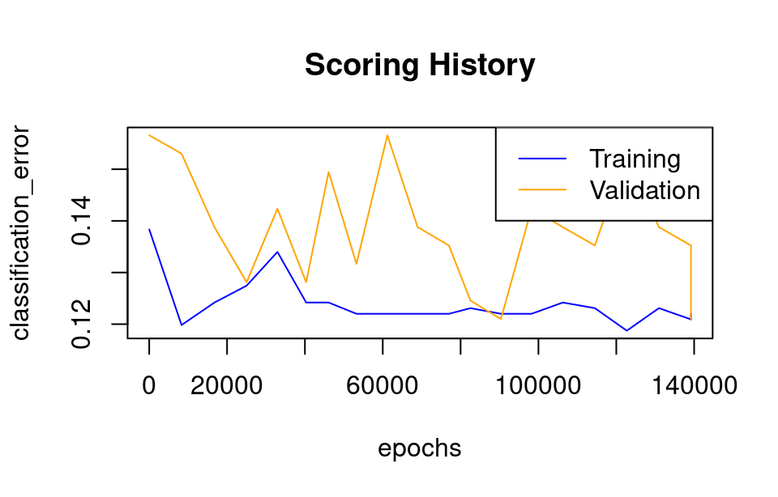

```r
plot(modelo)
```

### Random search

Dado el elevado número de hiperparámetros que tienen los modelos de redes neuronales, la combinación de posibles configuraciones es muy elevada. Esto hace que la búsqueda de hiperparámetros por *grid search* cartesiano (todas las combinaciones) sea poco práctica. En su lugar, suele emplearse *random grid search*, que hace una búsqueda de combinaciones aleatorias.

Algunas combinaciones aleatorias pueden ser muy poco favorables, por esta razón es conveniente activar la parada temprana.

```r
# Hiperparámetros que se quieren optimizar mediante búsqueda aleatoria.
# Se definen los posibles valores de cada hiperparámetro, entre los que se
# escoge aleatoriamente.

hiperparametros <- list(
                     activation = c("Rectifier", "Maxout", "Tanh", "RectifierWithDropout"),
                     hidden = list(c(5), c(10), c(50), c(10, 10)),
                     l1 = c(0, 0.00001, 0.0001),
                     l2 = c(0, 0.00001, 0.0001),
                     rate = c(0, 01, 0.005, 0.001),
                     rate_annealing = c(1e-8, 1e-7, 1e-6),
                     rho = c(0.9, 0.95, 0.99, 0.999),
                     epsilon = c(1e-10, 1e-8, 1e-6, 1e-4),
                     momentum_start = c(0, 0.5),
                     momentum_stable = c(0.99, 0.5, 0),
                     input_dropout_ratio = c(0, 0.1, 0.2),
                     max_w2 = c(10, 100, 1000, 3.4028235e+38)
                  )

# Al ser una búsqueda aleatoria, hay que indicar criterios de parada.
search_criteria <- list(
                    strategy = "RandomDiscrete",
                    max_runtime_secs   = 5*60, # Tiempo máximo de búsqueda (5 minutos)
                    max_models         = 100,  # Número máximo de modelos
                    stopping_tolerance = 0.01,
                    stopping_rounds    = 5,
                    seed               = 1234
                  )


grid_dl_4 <- h2o.grid(
              algorithm = "deeplearning",
              epochs    = 5000,
              x         = c("x_1", "x_2"),
              y         = "y",
              training_frame = datos_train,
              # validation_frame = datos_validation, # Validación simple
              nfolds           = 3, # validación cruzada
              standardize      = TRUE,
              hyper_params     = hiperparametros,
              search_criteria  = search_criteria,
              seed             = 123,
              grid_id          = "grid_dl_4"
            )
```

```r
resultados_grid <- h2o.getGrid(
                     sort_by    = 'accuracy',
                     grid_id    = "grid_dl_4",
                     decreasing = TRUE
                   )

data.frame(resultados_grid@summary_table)
```

| activation | epsilon | hidden | input_dropout_ratio | l1 | l2 | max_w2 | momentum_stable | momentum_start | rate | rate_annealing | rho | model_ids | accuracy |
| --- | --- | --- | --- | --- | --- | --- | --- | --- | --- | --- | --- | --- | --- |
| Tanh | 1.0E-10 | [5] | 0.2 | 1.0E-4 | 1.0E-5 | 100.0 | 0.5 | 0.0 | 1.0 | 1.0E-7 | 0.999 | grid_dl_4_model_14 | 0.8769063180827886 |
| Rectifier | 1.0E-10 | [10] | 0.1 | 0.0 | 1.0E-4 | 100.0 | 0.99 | 0.5 | 1.0 | 1.0E-7 | 0.95 | grid_dl_4_model_16 | 0.8758169934640523 |
| Rectifier | 1.0E-8 | [50] | 0.1 | 1.0E-4 | 1.0E-5 | 3.4028235E38 | 0.99 | 0.5 | 1.0 | 1.0E-7 | 0.99 | grid_dl_4_model_18 | 0.8758169934640523 |
| Tanh | 1.0E-6 | [10] | 0.2 | 0.0 | 1.0E-4 | 3.4028235E38 | 0.0 | 0.5 | 0.005 | 1.0E-6 | 0.95 | grid_dl_4_model_12 | 0.8725490196078431 |
| Maxout | 1.0E-10 | [10] | 0.1 | 1.0E-5 | 0.0 | 100.0 | 0.5 | 0.0 | 0.005 | 1.0E-6 | 0.99 | grid_dl_4_model_13 | 0.8725490196078431 |
| RectifierWithDropout | 1.0E-8 | [50] | 0.0 | 1.0E-5 | 0.0 | 10.0 | 0.99 | 0.0 | 0.005 | 1.0E-6 | 0.99 | grid_dl_4_model_7 | 0.8714596949891067 |
| Rectifier | 1.0E-8 | [5] | 0.2 | 1.0E-5 | 1.0E-4 | 1000.0 | 0.5 | 0.0 | 0.0 | 1.0E-7 | 0.99 | grid_dl_4_model_8 | 0.8714596949891067 |
| Rectifier | 1.0E-10 | [10, 10] | 0.0 | 1.0E-5 | 1.0E-4 | 1000.0 | 0.0 | 0.0 | 0.001 | 1.0E-7 | 0.9 | grid_dl_4_model_9 | 0.8714596949891067 |
| Tanh | 1.0E-6 | [10] | 0.0 | 1.0E-4 | 0.0 | 10.0 | 0.5 | 0.5 | 1.0 | 1.0E-6 | 0.999 | grid_dl_4_model_10 | 0.869281045751634 |
| RectifierWithDropout | 1.0E-6 | [50] | 0.0 | 1.0E-4 | 0.0 | 100.0 | 0.5 | 0.5 | 0.005 | 1.0E-7 | 0.9 | grid_dl_4_model_15 | 0.8681917211328976 |

[output cut: 11 more lines]

# Caso de uso: predicción de precios vivienda

El set de datos `SaratogaHouses` del paquete `mosaicData` contiene información sobre la precio de 1728 viviendas situadas en Saratoga County, New York, USA en el año 2006. Además del precio, incluye 15 variables adicionales:

- `price`: precio de la vivienda.
- `lotSize`: metros cuadrados de la vivienda.
- `age`: antigüedad de la vivienda.
- `landValue`: valor del terreno.
- `livingArea`: metros cuadrados habitables.
- `pctCollege`: porcentaje del vecindario con título universitario.
- `bedrooms`: número de dormitorios.
- `firplaces`: número de chimeneas.
- `bathrooms`: número de cuartos de baño (el valor 0.5 hace referencia a cuartos de baño sin ducha).
- `rooms`: número de habitaciones.
- `heating`: tipo de calefacción.
- `fuel`: tipo de alimentación de la calefacción (gas, electricidad o diesel).
- `sewer`: tipo de desagüe.
- `waterfront`: si la vivienda tiene vistas al lago.
- `newConstruction`: si la vivienda es de nueva construcción.
- `centralAir`: si la vivienda tiene aire acondicionado.

El objetivo es obtener un modelo de red neuronal capaz de predecir el precio de la vivienda.

## Paquetes

```r
# Tratamiento de datos y gráficos
# ==============================================================================
library(tidymodels)
library(tidyverse)
library(skimr)
library(DataExplorer)
library(ggpubr)
library(mosaicData)

# Modelado
# ==============================================================================
# sudo apt install default-jre
library(h2o)
```

## Datos

```r
data("SaratogaHouses", package = "mosaicData")
datos <- SaratogaHouses

# Se renombran las columnas para que sean más descriptivas
colnames(datos) <- c("precio", "metros_totales", "antiguedad", "precio_terreno",
                     "metros_habitables", "universitarios",
                     "dormitorios", "chimenea", "banyos", "habitaciones",
                     "calefaccion", "consumo_calefacion", "desague",
                     "vistas_lago","nueva_construccion", "aire_acondicionado")
```

## Análisis exploratorio

Antes de entrenar un modelo predictivo, o incluso antes de realizar cualquier cálculo con un nuevo conjunto de datos, es importante realizar una exploración descriptiva de los mismos. Este proceso permite entender mejor qué información contiene cada variable, así como detectar posibles errores.

**Tabla resumen**

```r
# Tabla resumen
# ==============================================================================
skim(datos)
```

Data summary

| Name | datos |
| --- | --- |
| Number of rows | 1728 |
| Number of columns | 16 |
| _______________________ |  |
| Column type frequency: |  |
| factor | 6 |
| numeric | 10 |
| ________________________ |  |
| Group variables | None |

**Variable type: factor**

| skim_variable | n_missing | complete_rate | ordered | n_unique | top_counts |
| --- | --- | --- | --- | --- | --- |
| calefaccion | 0 | 1 | FALSE | 3 | hot: 1121, ele: 305, hot: 302 |
| consumo_calefacion | 0 | 1 | FALSE | 3 | gas: 1197, ele: 315, oil: 216 |
| desague | 0 | 1 | FALSE | 3 | pub: 1213, sep: 503, non: 12 |
| vistas_lago | 0 | 1 | FALSE | 2 | No: 1713, Yes: 15 |
| nueva_construccion | 0 | 1 | FALSE | 2 | No: 1647, Yes: 81 |
| aire_acondicionado | 0 | 1 | FALSE | 2 | No: 1093, Yes: 635 |

**Variable type: numeric**

| skim_variable | n_missing | complete_rate | mean | sd | p0 | p25 | p50 | p75 | p100 | hist |
| --- | --- | --- | --- | --- | --- | --- | --- | --- | --- | --- |
| precio | 0 | 1 | 211966.71 | 98441.39 | 5000 | 1.45e+05 | 189900.00 | 259000.00 | 775000.0 | ▅▇▂▁▁ |
| metros_totales | 0 | 1 | 0.50 | 0.70 | 0 | 1.70e-01 | 0.37 | 0.54 | 12.2 | ▇▁▁▁▁ |
| antiguedad | 0 | 1 | 27.92 | 29.21 | 0 | 1.30e+01 | 19.00 | 34.00 | 225.0 | ▇▁▁▁▁ |
| precio_terreno | 0 | 1 | 34557.19 | 35021.17 | 200 | 1.51e+04 | 25000.00 | 40200.00 | 412600.0 | ▇▁▁▁▁ |
| metros_habitables | 0 | 1 | 1754.98 | 619.94 | 616 | 1.30e+03 | 1634.50 | 2137.75 | 5228.0 | ▇▇▂▁▁ |
| universitarios | 0 | 1 | 55.57 | 10.33 | 20 | 5.20e+01 | 57.00 | 64.00 | 82.0 | ▁▃▆▇▁ |
| dormitorios | 0 | 1 | 3.15 | 0.82 | 1 | 3.00e+00 | 3.00 | 4.00 | 7.0 | ▃▇▅▁▁ |
| chimenea | 0 | 1 | 0.60 | 0.56 | 0 | 0.00e+00 | 1.00 | 1.00 | 4.0 | ▆▇▁▁▁ |
| banyos | 0 | 1 | 1.90 | 0.66 | 0 | 1.50e+00 | 2.00 | 2.50 | 4.5 | ▁▇▇▁▁ |
| habitaciones | 0 | 1 | 7.04 | 2.32 | 2 | 5.00e+00 | 7.00 | 8.25 | 12.0 | ▃▇▇▅▂ |

Todas las columnas tienen el tipo adecuado.

```r
# Número de datos ausentes por variable
# ==============================================================================
datos %>% map_dbl(.f = function(x){sum(is.na(x))})
```

```
##             precio     metros_totales         antiguedad     precio_terreno
##                  0                  0                  0                  0
##  metros_habitables     universitarios        dormitorios           chimenea
##                  0                  0                  0                  0
##             banyos       habitaciones        calefaccion consumo_calefacion
##                  0                  0                  0                  0
##            desague        vistas_lago nueva_construccion aire_acondicionado
##                  0                  0                  0                  0
```

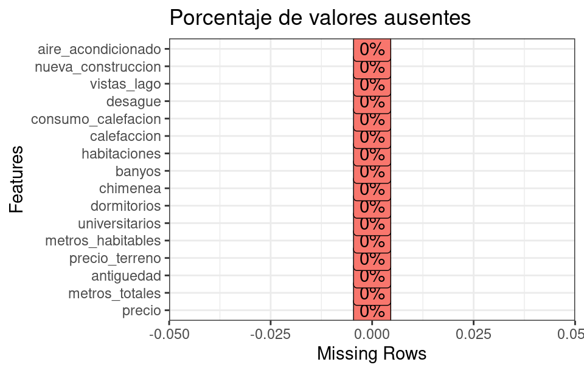

```r
plot_missing(
  data    = datos,
  title   = "Porcentaje de valores ausentes",
  ggtheme = theme_bw(),
  theme_config = list(legend.position = "none")
)
```

Todas las columnas están completas, no hay valores ausentes.

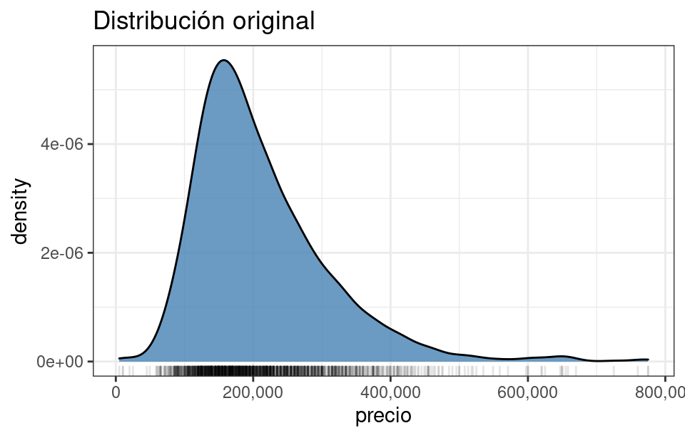

```r
# Distribución variable respuesta
# ==============================================================================
ggplot(data = datos, aes(x = precio)) +
  geom_density(fill = "steelblue", alpha = 0.8) +
  geom_rug(alpha = 0.1) +
  scale_x_continuous(labels = scales::comma) +
  labs(title = "Distribución original") +
  theme_bw()
```

```r
# Tabla de estadísticos principales
summary(datos$precio)
```

```
##    Min. 1st Qu.  Median    Mean 3rd Qu.    Max.
##    5000  145000  189900  211967  259000  775000
```

Los modelos de redes neuronales son de tipo no paramétrico, no asumen ningún tipo de distribución de la variable respuesta, por lo tanto, no es necesario que esta siga ninguna distribución concreta (normal, gamma…). Aun así, siempre es recomendable hacer un estudio mínimo, ya que, a fin de cuentas, es lo que interesa predecir. En este caso, la variable precio tiene una distribución asimétrica con una cola positiva debido a que, unas pocas viviendas, tienen un precio muy superior a la media.

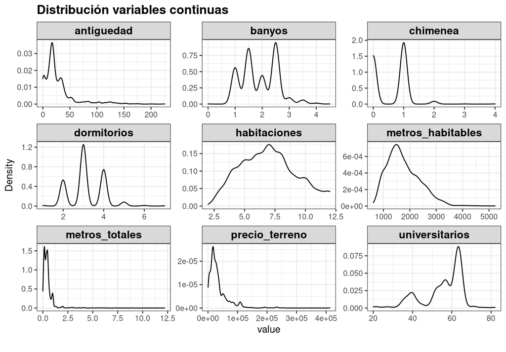

```r
# Gráfico de distribución para cada variable numérica
# ==============================================================================
plot_density(
  data    = datos %>% select(-precio),
  ncol    = 3,
  title   = "Distribución variables continuas",
  ggtheme = theme_bw(),
  theme_config = list(
                  plot.title = element_text(size = 14, face = "bold"),
                  strip.text = element_text(colour = "black", size = 12, face = 2)
                 )
  )
```

La variable `chimenea`, aunque es de tipo numérico, apenas toma unos pocos valores y la gran mayoría de observaciones pertenecen a solo dos de ellos. En casos como este, suele ser conveniente tratar la variable como cualitativa.

```r
# Valores observados de chimenea
# ==============================================================================
table(datos$chimenea)
```

```
##
##   0   1   2   3   4
## 740 942  42   2   2
```

```r
# Se convierte la variable chimenea a factor.
datos <- datos %>%
         mutate(chimenea = as.factor(chimenea))
```

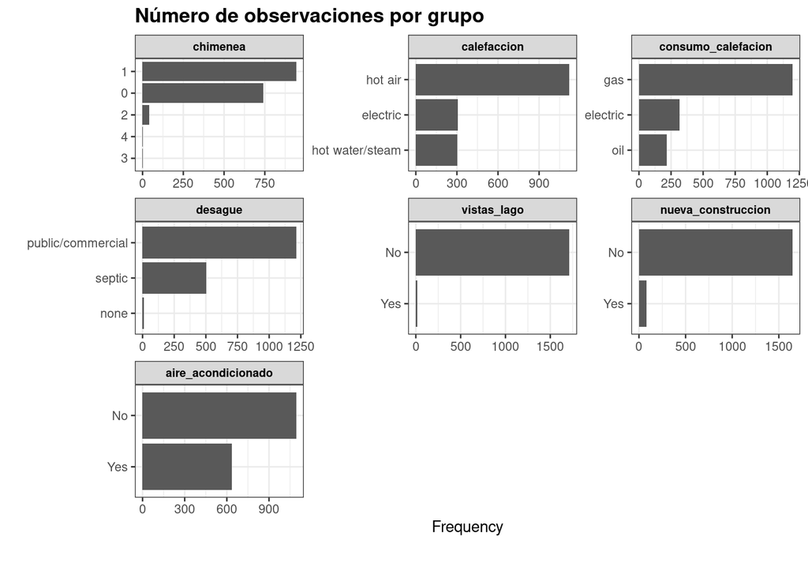

```r
# Gráfico para cada variable cualitativa
# ==============================================================================
plot_bar(
  datos,
  ncol    = 3,
  title   = "Número de observaciones por grupo",
  ggtheme = theme_bw(),
  theme_config = list(
                   plot.title = element_text(size = 14, face = "bold"),
                   strip.text = element_text(colour = "black", size = 8, face = 2),
                   legend.position = "none"
                  )
)
```

Si alguno de los niveles de una variable cualitativa tiene muy pocas observaciones en comparación a los otros niveles, puede ocurrir que, durante la validación cruzada o bootstrapping, algunas particiones no contengan ninguna observación de dicha clase (varianza cero), lo que puede dar lugar a errores. Para este caso, hay que tener precaución con la variable chimenea. Se unifican los niveles de 2, 3 y 4 en un nuevo nivel llamado “2_mas”.

```r
table(datos$chimenea)
```

```
##
##   0   1   2   3   4
## 740 942  42   2   2
```

```r
datos <- datos %>%
         mutate(
           chimenea = recode_factor(
                        chimenea,
                        `2` = "2_mas",
                        `3` = "2_mas",
                        `4` = "2_mas"
                      )
         )

table(datos$chimenea)
```

```
##
## 2_mas     0     1
##    46   740   942
```

## División train y test

Con el objetivo de poder estimar el error que comete el modelo al predecir nuevas observaciones, se dividen los datos en dos grupos, uno de entrenamiento y otro de test (80%, 20%).

```r
# Reparto de datos en train y test
# ==============================================================================
set.seed(123)
split_inicial <- initial_split(
                    data   = datos,
                    prop   = 0.8,
                    strata = precio
                 )

datos_train <- training(split_inicial)
datos_test  <- testing(split_inicial)
```

Tras realizar el reparto, se verifica que los dos grupos son similares.

```r
summary(datos_train$precio)
```

```
##    Min. 1st Qu.  Median    Mean 3rd Qu.    Max.
##    5000  145000  189050  212423  259000  775000
```

```r
summary(datos_test$precio)
```

```
##    Min. 1st Qu.  Median    Mean 3rd Qu.    Max.
##   20000  145000  189950  210157  257750  620000
```

## Preprocesado

Los modelos de redes neuronales requieren como mínimo de dos tipos de preprocesado: binarización (one hot encoding) de las variables categóricas y estandarización de las variables continuas.

```r
# Se almacenan en un objeto `recipe` todos los pasos de preprocesado y, finalmente,
# se aplican a los datos.
transformer <- recipe(
                  formula = precio ~ .,
                  data =  datos_train
               ) %>%
               step_naomit(all_predictors()) %>%
               step_nzv(all_predictors()) %>%
               step_center(all_numeric(), -all_outcomes()) %>%
               step_scale(all_numeric(), -all_outcomes()) %>%
               step_dummy(all_nominal(), -all_outcomes())

transformer
```

```
## Data Recipe
##
## Inputs:
##
##       role #variables
##    outcome          1
##  predictor         15
##
## Operations:
##
## Removing rows with NA values in all_predictors()
## Sparse, unbalanced variable filter on all_predictors()
## Centering for all_numeric(), -all_outcomes()
## Scaling for all_numeric(), -all_outcomes()
## Dummy variables from all_nominal(), -all_outcomes()
```

Una vez que se ha definido el objeto `recipe`, con la función `prep()` se aprenden las transformaciones con los datos de entrenamiento y se aplican a los dos conjuntos con `bake()`.

```r
# Se entrena el objeto recipe
transformer_fit <- prep(transformer)

# Se aplican las transformaciones al conjunto de entrenamiento y de test
datos_train_prep <- bake(transformer_fit, new_data = datos_train)
datos_test_prep  <- bake(transformer_fit, new_data = datos_test)

glimpse(datos_train_prep)
```

```
## Rows: 1,380
## Columns: 19
## $ metros_totales              <dbl> -0.43894231, 0.26607619, 0.48189818, 0.611…
## $ antiguedad                  <dbl> 3.6226807, 0.1147142, 0.2866733, -0.917040…
## $ precio_terreno              <dbl> -0.7674967, -0.5829431, -0.3570715, -0.354…
## $ metros_habitables           <dbl> 0.31203819, -0.96981699, -0.19293506, -0.2…
## $ universitarios              <dbl> -0.4558859, -3.2928560, -0.4558859, -0.455…
## $ dormitorios                 <dbl> 1.0465989, 1.0465989, -0.1681248, -0.16812…
## $ banyos                      <dbl> -1.3602353, -1.3602353, -0.6045490, 0.1511…
## $ habitaciones                <dbl> 0.425229547, 0.425229547, 0.425229547, -0.…
## $ precio                      <int> 109000, 120000, 90000, 120000, 85860, 1270…
## $ chimenea_X0                 <dbl> 0, 0, 1, 1, 1, 1, 1, 1, 1, 1, 1, 0, 0, 1, …
## $ chimenea_X1                 <dbl> 1, 1, 0, 0, 0, 0, 0, 0, 0, 0, 0, 1, 0, 0, …
## $ calefaccion_hot.water.steam <dbl> 1, 0, 0, 0, 0, 0, 1, 1, 0, 0, 0, 0, 1, 0, …
## $ calefaccion_electric        <dbl> 0, 0, 1, 0, 1, 0, 0, 0, 0, 1, 1, 0, 0, 0, …
## $ consumo_calefacion_electric <dbl> 0, 0, 1, 0, 1, 0, 0, 0, 0, 1, 1, 0, 0, 0, …
## $ consumo_calefacion_oil      <dbl> 0, 0, 0, 0, 0, 1, 0, 1, 1, 0, 0, 1, 1, 1, …
## $ desague_public.commercial   <dbl> 1, 0, 0, 0, 0, 0, 1, 0, 0, 0, 1, 0, 0, 0, …
## $ desague_none                <dbl> 0, 0, 0, 0, 0, 0, 0, 0, 0, 0, 0, 0, 0, 0, …
## $ nueva_construccion_No       <dbl> 1, 1, 1, 1, 1, 1, 1, 1, 1, 1, 1, 1, 1, 1, …
## $ aire_acondicionado_No       <dbl> 1, 1, 1, 1, 1, 1, 1, 1, 1, 1, 1, 0, 1, 1, …
```

Tras el preprocesado de los datos, se han generado un total de 19 variables (18 predictores y la variable respuesta).

## Modelado

```r
# Inicialización del cluster
# ==============================================================================
h2o.init(
  nthreads = -1,
  max_mem_size = "4g"
)
```

```
##  Connection successful!
##
## R is connected to the H2O cluster:
##     H2O cluster uptime:         4 hours 42 minutes
##     H2O cluster timezone:       Europe/Madrid
##     H2O data parsing timezone:  UTC
##     H2O cluster version:        3.32.1.3
##     H2O cluster version age:    1 month and 22 days
##     H2O cluster name:           H2O_started_from_R_ximo_tcy429
##     H2O cluster total nodes:    1
##     H2O cluster total memory:   5.91 GB
##     H2O cluster total cores:    8
##     H2O cluster allowed cores:  8
##     H2O cluster healthy:        TRUE
##     H2O Connection ip:          localhost
##     H2O Connection port:        54321
##     H2O Connection proxy:       NA
##     H2O Internal Security:      FALSE
##     H2O API Extensions:         Amazon S3, XGBoost, Algos, AutoML, Core V3, TargetEncoder, Core V4
##     R Version:                  R version 4.1.0 (2021-05-18)
```

```r
# Se eliminan los datos del cluster por si ya había sido iniciado.
h2o.removeAll()
h2o.no_progress()
```

Se transfieren los datos al cluster de H2O..

```r
datos_train  <- as.h2o(datos_train_prep, key = "datos_train")
datos_test   <- as.h2o(datos_test_prep, key = "datos_test")
```

```r
# Espacio de búsqueda de cada hiperparámetro
# ==============================================================================
hiperparametros <- list(
                      epochs = c(50, 100, 500),
                      hidden = list(5, 10, 25, 50, c(10, 10))
                    )


# Búsqueda por validación cruzada
# ==============================================================================
variable_respuesta <- 'precio'
predictores <- setdiff(colnames(datos_train), variable_respuesta)

grid <- h2o.grid(
              algorithm    = "deeplearning",
              activation   = "Rectifier",
              x            = predictores,
              y            = variable_respuesta,
              training_frame  = datos_train,
              nfolds       = 3, #validacion cruzada
              standardize  = FALSE,
              hyper_params = hiperparametros,
              search_criteria = list(strategy = "Cartesian"),
              seed         = 123,
              grid_id      = "grid"
          )
```

```r
# Resultados del grid
# ==============================================================================
resultados_grid <- h2o.getGrid(
                     sort_by = 'rmse',
                     grid_id = "grid",
                     decreasing = FALSE
                   )
data.frame(resultados_grid@summary_table)
```

| epochs | hidden | model_ids | rmse |
| --- | --- | --- | --- |
| 504.55422521143527 | [50] | grid_model_12 | 64327.002005632814 |
| 504.55422521143527 | [10] | grid_model_6 | 64912.91827896282 |
| 504.55422521143527 | [25] | grid_model_9 | 64944.60746373326 |
| 504.55422521143527 | [10, 10] | grid_model_15 | 66783.8146579155 |
| 52.200937848628 | [10, 10] | grid_model_13 | 67457.1770639292 |
| 104.45216680194142 | [10, 10] | grid_model_14 | 67538.14218979987 |
| 504.55422521143527 | [5] | grid_model_3 | 69952.28922884271 |
| 104.45216680194142 | [50] | grid_model_11 | 71082.27164931098 |
| 52.200937848628 | [50] | grid_model_10 | 71120.20143966247 |
| 104.45216680194142 | [25] | grid_model_8 | 72448.38337339456 |

[output cut: 5 more lines]

```r
# Mejor modelo encontrado
# ==============================================================================
modelo_final <- h2o.getModel(resultados_grid@model_ids[[1]])
```

## Error de test

Aunque mediante los métodos de validación se consiguen buenas estimaciones del error que tiene un modelo al predecir nuevas observaciones, la mejor forma de evaluar un modelo final es prediciendo un conjunto test, es decir, un conjunto de observaciones que se ha mantenido al margen del proceso de entrenamiento y optimización.

```r
predicciones <- h2o.predict(
                  object  = modelo_final,
                  newdata = datos_test
                )

predicciones <- predicciones %>%
                as_tibble() %>%
                mutate(valor_real = as.vector(datos_test$precio))

predicciones %>% head(5)
```

| predict | valor_real |
| --- | --- |
| 135015.77 | 132500 |
| 231716.63 | 181115 |
| 31457.33 | 86060 |
| 227145.50 | 153000 |
| 188526.43 | 122900 |

```r
rmse(predicciones, truth = valor_real, estimate = predict, na_rm = TRUE)
```

| .metric | .estimator | .estimate |
| --- | --- | --- |
| rmse | standard | 55422.31 |

## Conclusión

La combinación de hiperparámetros con la que se obtienen mejores resultados acorde a las métricas de validación cruzada es:

```r
modelo_final@allparameters
```

```
## $model_id
## [1] "grid_model_12"
##
## $training_frame
## [1] "datos_train_prep_sid_a36b_13"
##
## $nfolds
## [1] 3
##
## $keep_cross_validation_models
## [1] TRUE
##
## $keep_cross_validation_predictions
## [1] FALSE
##
## $keep_cross_validation_fold_assignment
## [1] FALSE
##
## $fold_assignment
## [1] "Random"
##
## $ignore_const_cols
## [1] TRUE
##
## $score_each_iteration
## [1] FALSE
##
## $balance_classes
## [1] FALSE
##
## $max_after_balance_size
## [1] 5
##
## $max_confusion_matrix_size
## [1] 20
##
## $overwrite_with_best_model
## [1] FALSE
##
## $use_all_factor_levels
```

[output cut: 183 more lines]

```
## [1] "AUTO"
##
## $x
##  [1] "metros_totales"              "antiguedad"
##  [3] "precio_terreno"              "metros_habitables"
##  [5] "universitarios"              "dormitorios"
##  [7] "banyos"                      "habitaciones"
##  [9] "chimenea_X0"                 "chimenea_X1"
## [11] "calefaccion_hot.water.steam" "calefaccion_electric"
## [13] "consumo_calefacion_electric" "consumo_calefacion_oil"
## [15] "desague_public.commercial"   "desague_none"
## [17] "nueva_construccion_No"       "aire_acondicionado_No"
##
## $y
## [1] "precio"
```

```r
# Se apaga el cluster H2O
#h2o.shutdown(prompt = FALSE)
```

# Información sesión

```r
sesion_info <- devtools::session_info()
dplyr::select(
  tibble::as_tibble(sesion_info$packages),
  c(package, loadedversion, source)
)
```

# Bibliografía

The Elements of Statistical Learning (2nd edition)

Hastie, Tibshirani and Friedman (2009). Springer-Verlag.

Applied Predictive Modeling by Max Kuhn and Kjell Johnson

Deep Learning by Josh Patterson, Adam Gibson

**¿Cómo citar este documento?**

Redes neuronales con R por Joaquín Amat Rodrigo, disponible con licencia CC BY-NC-SA 4.0 en https://www.cienciadedatos.net/documentos/68-redes-neuronales-r.html

**¿Te ha gustado el artículo? Tu ayuda es importante**

Mantener un sitio web tiene unos costes elevados, tu contribución me ayudará a seguir generando contenido divulgativo gratuito. ¡Muchísimas gracias! 😊

Este material, creado por Joaquín Amat Rodrigo, tiene licencia [Attribution-NonCommercial-ShareAlike 4.0 International](https://creativecommons.org/licenses/by-nc-sa/4.0/).

Se permite:

- Compartir: copiar y redistribuir el material en cualquier medio o formato.
- Adaptar: remezclar, transformar y crear a partir del material.

Bajo los siguientes términos:

- Atribución: Debes otorgar [el crédito adecuado](https://creativecommons.org/licenses/by-nc-sa/4.0/deed.es#ref-appropriate-credit), proporcionar un enlace a la licencia e [indicar si se realizaron cambios](https://creativecommons.org/licenses/by-nc-sa/4.0/deed.es#ref-indicate-changes). Puedes hacerlo de cualquier manera razonable, pero no de una forma que sugiera que el licenciante te respalda o respalda tu uso.
- NoComercial: No puedes utilizar el material para [fines comerciales](https://creativecommons.org/licenses/by-nc-sa/4.0/deed.es#ref-commercial-purposes).
- CompartirIgual: Si remezclas, transformas o creas a partir del material, debes distribuir tus contribuciones bajo la [misma licencia](https://creativecommons.org/licenses/by-nc-sa/4.0/deed.es#ref-same-license) que el original.